# Les différents polluants en region centre

# et finalement pour les pm2.5:

```r
carte5 <- leaflet::leaflet() %>%
  leaflet::addTiles() %>%
  leaflet::setView(lng = 1.693130, lat = 46.79827, zoom = 12)
print (carte5)
#on attribue les variables longitude, latitude et radius
Longi <- Pm2.5$attributes.x_wgs84
Latti <- Pm2.5$attributes.y_wgs84
radius2 <- Pm2.5$moyenne
#on place les points sur la carte
carte5 <- carte5 %>%
  leaflet::addCircleMarkers(lng = Longi, lat = Latti, weight = 1, radius = radius2*6, color = "green")
print (carte5)

## Sauvegarde de la carte
htmlwidgets::saveWidget(widget=carte5, file="ma_carte_5.html", selfcontained = TRUE)
## Affichage  de la carte
htmltools::tags$iframe(title = "Ma carte5", width = "700", height = "700", src = "ma_carte_5.html")
```

[interactive chart not shown]

Apercu de la solution annexe developpé ce week-end:

# Ici on inclut la carte qui rend compte des taux de pollution pour le NO dans nos villes selectionnées:

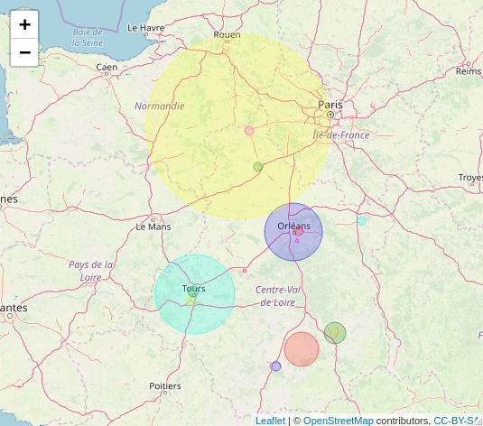

```r
knitr::include_graphics("graphiqueNO.png")
```

# Ici on inclut la carte qui rend compte des taux de pollutions pour le NO2 dans nos villes selectionnées:

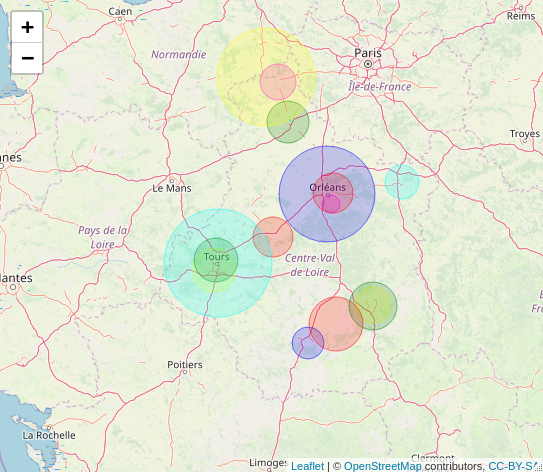

```r
knitr::include_graphics("graphique NO2.png")
```

# Ici on met en place un graphique qui résume les différents taux de pollution pour les villes sélectionnées:

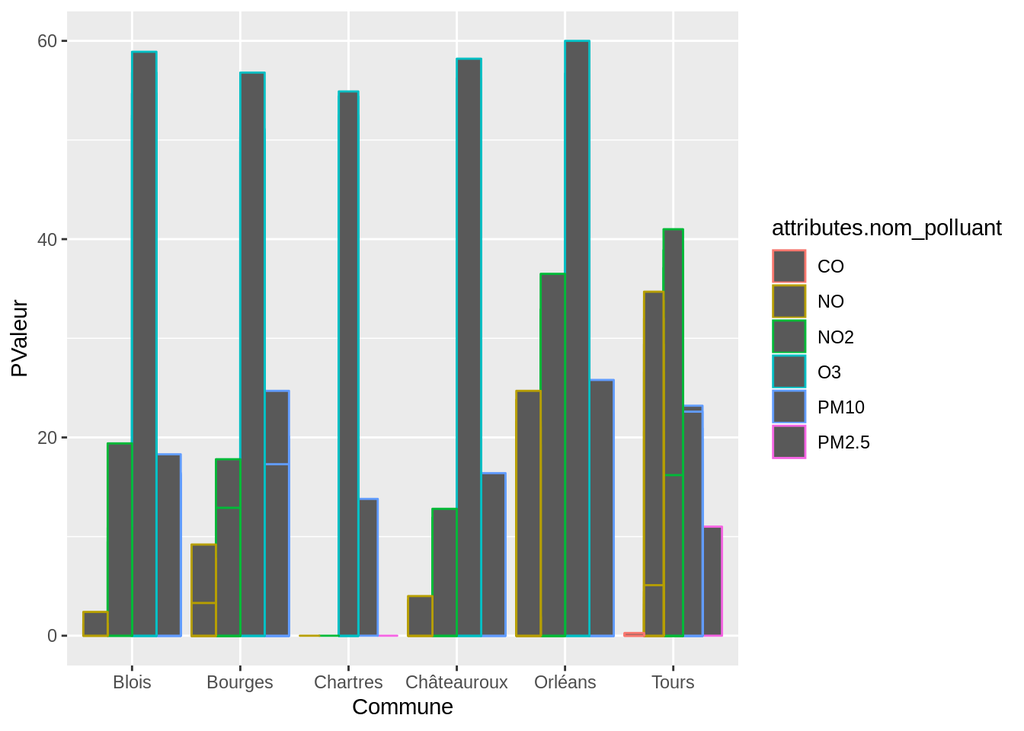

```r
Commune<-Projetn$attributes.nom_com
PValeur<-Projetn$attributes.valeur

ggplot(data = Projetn, aes(x=Commune, y=PValeur, color = attributes.nom_polluant)) + geom_bar(position = "dodge", stat = "Identity")
```